# 比較群変更に関する頑健性確認

Ayumu Tanaka

2026-05-28

# 1 パッケージの読み込み

```r
library(tidyverse)
library(fixest)
library(etwfe)
library(modelsummary)
library(kableExtra)
options("modelsummary_format_numeric_latex" = "plain")
```

# 2 データの読み込みと整形

Non-EU high-income comparison countries: CAN, AUS, CHE, KOR, NZL.

```r
library(rio)
aff <- rio::import("../../03_data_output/Affiliate/affiliate_panel_brexit_full_sample.dta")

NonEU_HI <- c("GBR", "CAN", "AUS", "CHE", "KOR", "NZL")

aff_nonEU <- aff %>%
  filter(country %in% NonEU_HI,
         year >= 2010, year <= 2020)

add_two_year_period <- function(data) {
  data %>%
    mutate(
      year_2 = case_when(
        year %in% 2010:2011 ~ 2010L,
        year %in% 2012:2013 ~ 2012L,
        year %in% 2014:2015 ~ 2014L,
        year %in% 2016:2017 ~ 2016L,
        year %in% 2018:2019 ~ 2018L,
        year == 2020 ~ 2020L,
        TRUE ~ NA_integer_
      )
    )
}

aff_nonEU <- add_two_year_period(aff_nonEU)

cat("N rows:", nrow(aff_nonEU), "\n")
```

```
## N rows: 10170
```

```r
print(table(aff_nonEU$country))
```

```
##
##  AUS  CAN  CHE  GBR  KOR  NZL
## 1914  894  222 2976 3900  264
```

```r
# Combined comparison: EU high-income + Non-EU high-income
EU_HI    <- c("AUT", "BEL", "DEU", "DNK", "FIN", "FRA", "IRL", "ITA", "LUX", "NLD", "SWE")
Combined <- c("GBR", EU_HI, "CAN", "AUS", "CHE", "KOR", "NZL")

aff_combined <- aff %>%
  filter(country %in% Combined,
         year >= 2010, year <= 2020)

aff_combined <- add_two_year_period(aff_combined)

cat("\nCombined N rows:", nrow(aff_combined), "\n")
```

```
##
## Combined N rows: 17358
```

```r
print(table(aff_combined$country))
```

```
##
##  AUS  AUT  BEL  CAN  CHE  DEU  DNK  FIN  FRA  GBR  IRL  ITA  KOR  LUX  NLD  NZL
## 1914  108  570  894  222 2640   96   66 1188 2976  126  564 3900   60 1596  264
##  SWE
##  174
```

# 3 TWFE OLS Event Study

```r
es_twfe <- fixest::feols(
  exitit ~ i(year_2, GBR, 2014) | year_2 + AffiliateCode,
  data = aff_nonEU,
  vcov = ~ country
)
fixest::etable(es_twfe)
```

```
##                               es_twfe
## Dependent Var.:                exitit
##
## GBR x year_2 = 2010 -0.0494* (0.0152)
## GBR x year_2 = 2012  -0.0198 (0.0100)
## GBR x year_2 = 2016  0.0163. (0.0065)
## GBR x year_2 = 2018   0.0114 (0.0157)
## GBR x year_2 = 2020   0.0315 (0.0181)
## Fixed-Effects:      -----------------
## year_2                            Yes
## AffiliateCode                     Yes
## ___________________ _________________
## S.E.: Clustered           by: country
## Observations                   10,170
## R2                            0.65518
## Within R2                     0.00263
## ---
## Signif. codes: 0 '***' 0.001 '**' 0.01 '*' 0.05 '.' 0.1 ' ' 1
```

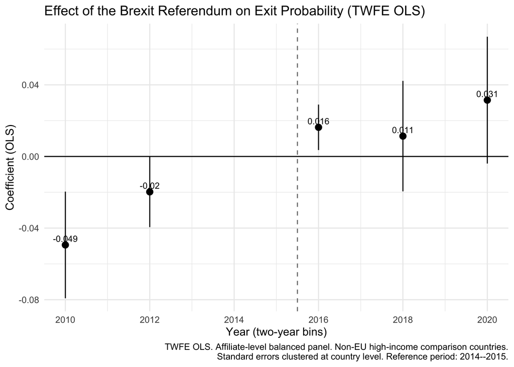

```r
# Extract coeftable for ggplot
ct <- as.data.frame(fixest::coeftable(es_twfe, vcov = ~ country))
ct$year  <- c(2010, 2012, 2016, 2018, 2020)
ct$lower <- ct$Estimate - 1.96 * ct$`Std. Error`
ct$upper <- ct$Estimate + 1.96 * ct$`Std. Error`

ggplot(ct, aes(x = year, y = Estimate, ymin = lower, ymax = upper)) +
  geom_hline(yintercept = 0) +
  geom_vline(xintercept = 2015.5, linetype = "dashed", color = "grey50") +
  geom_pointrange() +
  geom_text(aes(label = round(Estimate, 3)), vjust = -0.5, hjust = 0.5, size = 3) +
  scale_x_continuous(breaks = c(2010, 2012, 2014, 2016, 2018, 2020)) +
  labs(x = "Year (two-year bins)", y = "Coefficient (OLS)",
       title = "Effect of the Brexit Referendum on Exit Probability (TWFE OLS)",
       caption = "TWFE OLS. Affiliate-level balanced panel. Non-EU high-income comparison countries.\nStandard errors clustered at country level. Reference period: 2014--2015.") +
  theme_minimal()
```

# 4 Pooled Logit QMLE DiD Event Study

```r
es_etwfe_logit <- etwfe::etwfe(
  exitit ~ 1,
  tvar   = year_2,
  gvar   = first_year,
  data   = aff_nonEU,
  family = "logit",
  vcov   = ~ country
)
fixest::etable(es_etwfe_logit)
```

```
##                                                 es_etwfe_logit
## Dependent Var.:                                         exitit
##
## Constant                                    -18.67*** (0.0357)
## first_year = 2016                           0.3334*** (0.0975)
## year_2 = 2012                                16.23*** (0.0499)
## year_2 = 2014                                17.04*** (0.0698)
## year_2 = 2016                                17.48*** (0.0788)
## year_2 = 2018                                17.81*** (0.1082)
## year_2 = 2020                                17.98*** (0.1109)
## .Dtreat x first_year = 2016 x year_2 = 2016    0.0048 (0.0370)
## .Dtreat x first_year = 2016 x year_2 = 2018   -0.0564 (0.0593)
## .Dtreat x first_year = 2016 x year_2 = 2020    0.0127 (0.0606)
## ________________________________________    __________________
## S.E.: Clustered                                    by: country
## Observations                                            10,170
## Squared Cor.                                           0.10202
## Pseudo R2                                              0.13145
## BIC                                                    8,893.9
## ---
## Signif. codes: 0 '***' 0.001 '**' 0.01 '*' 0.05 '.' 0.1 ' ' 1
```

```r
es_etwfe_logit_me <- etwfe::emfx(es_etwfe_logit, type = "event")
print(es_etwfe_logit_me)
```

```
##
##  event  Estimate Std. Error      z Pr(>|z|)   S   2.5 % 97.5 %
##      0  0.000997    0.00773  0.129    0.897 0.2 -0.0142 0.0161
##      2 -0.013049    0.01381 -0.945    0.345 1.5 -0.0401 0.0140
##      4  0.003090    0.01468  0.210    0.833 0.3 -0.0257 0.0319
##
## Term: .Dtreat
## Type: response
## Comparison: TRUE - FALSE
```

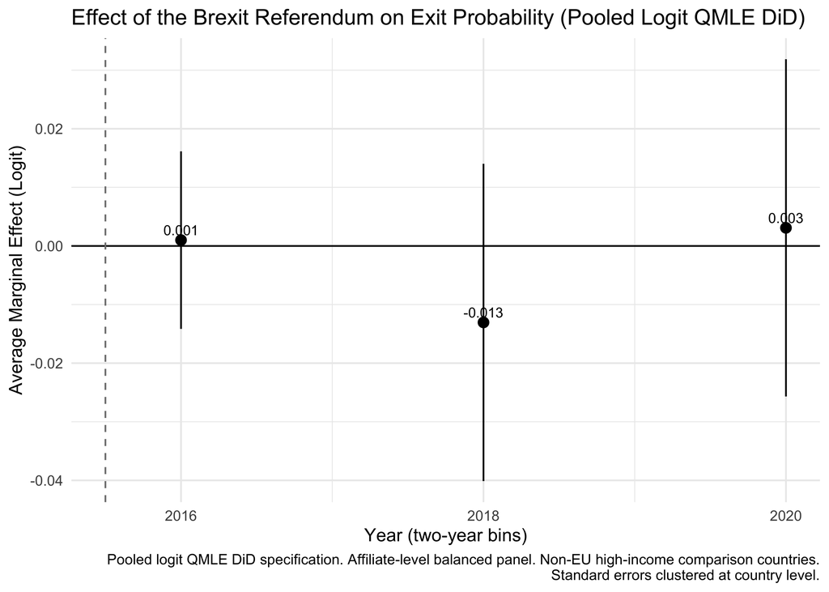

```r
es_etwfe_logit_me$year <- es_etwfe_logit_me$event + 2016

ggplot(es_etwfe_logit_me, aes(x = year, y = estimate,
                               ymin = conf.low, ymax = conf.high)) +
  geom_hline(yintercept = 0) +
  geom_vline(xintercept = 2015.5, linetype = "dashed", color = "grey50") +
  geom_pointrange() +
  geom_text(aes(label = round(estimate, 3)), vjust = -0.5, hjust = 0.5, size = 3) +
  scale_x_continuous(breaks = c(2016, 2018, 2020)) +
  labs(x = "Year (two-year bins)", y = "Average Marginal Effect (Logit)",
       title = "Effect of the Brexit Referendum on Exit Probability (Pooled Logit QMLE DiD)",
       caption = "Pooled logit QMLE DiD specification. Affiliate-level balanced panel. Non-EU high-income comparison countries.\nStandard errors clustered at country level.") +
  theme_minimal()
```

# 5 Combined Comparison: TWFE OLS Event Study

```r
es_twfe_comb <- fixest::feols(
  exitit ~ i(year_2, GBR, 2014) | year_2 + AffiliateCode,
  data = aff_combined,
  vcov = ~ country
)
fixest::etable(es_twfe_comb)
```

```
##                         es_twfe_comb
## Dependent Var.:               exitit
##
## GBR x year_2 = 2010 -0.0264 (0.0174)
## GBR x year_2 = 2012 -0.0110 (0.0095)
## GBR x year_2 = 2016  0.0129 (0.0080)
## GBR x year_2 = 2018  0.0084 (0.0115)
## GBR x year_2 = 2020 0.0310* (0.0138)
## Fixed-Effects:      ----------------
## year_2                           Yes
## AffiliateCode                    Yes
## ___________________ ________________
## S.E.: Clustered          by: country
## Observations                  17,358
## R2                           0.66121
## Within R2                    0.00084
## ---
## Signif. codes: 0 '***' 0.001 '**' 0.01 '*' 0.05 '.' 0.1 ' ' 1
```

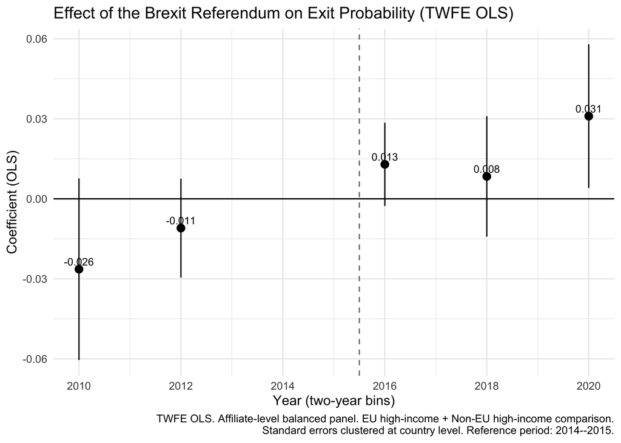

```r
ct_comb <- as.data.frame(fixest::coeftable(es_twfe_comb, vcov = ~ country))
ct_comb$year  <- c(2010, 2012, 2016, 2018, 2020)
ct_comb$lower <- ct_comb$Estimate - 1.96 * ct_comb$`Std. Error`
ct_comb$upper <- ct_comb$Estimate + 1.96 * ct_comb$`Std. Error`

ggplot(ct_comb, aes(x = year, y = Estimate, ymin = lower, ymax = upper)) +
  geom_hline(yintercept = 0) +
  geom_vline(xintercept = 2015.5, linetype = "dashed", color = "grey50") +
  geom_pointrange() +
  geom_text(aes(label = round(Estimate, 3)), vjust = -0.5, hjust = 0.5, size = 3) +
  scale_x_continuous(breaks = c(2010, 2012, 2014, 2016, 2018, 2020)) +
  labs(x = "Year (two-year bins)", y = "Coefficient (OLS)",
       title = "Effect of the Brexit Referendum on Exit Probability (TWFE OLS)",
       caption = "TWFE OLS. Affiliate-level balanced panel. EU high-income + Non-EU high-income comparison.\nStandard errors clustered at country level. Reference period: 2014--2015.") +
  theme_minimal()
```

# 6 Combined Comparison: Pooled Logit QMLE DiD Event Study

```r
es_etwfe_logit_comb <- etwfe::etwfe(
  exitit ~ 1,
  tvar   = year_2,
  gvar   = first_year,
  data   = aff_combined,
  family = "logit",
  vcov   = ~ country
)
fixest::etable(es_etwfe_logit_comb)
```

```
##                                             es_etwfe_logit_c..
## Dependent Var.:                                         exitit
##
## Constant                                    -18.60*** (0.0214)
## first_year = 2016                              0.1667 (0.1088)
## year_2 = 2012                                16.32*** (0.0828)
## year_2 = 2014                                17.13*** (0.0917)
## year_2 = 2016                                17.55*** (0.0980)
## year_2 = 2018                                17.85*** (0.0990)
## year_2 = 2020                                18.01*** (0.1020)
## .Dtreat x first_year = 2016 x year_2 = 2016    0.0291 (0.0383)
## .Dtreat x first_year = 2016 x year_2 = 2018   -0.0114 (0.0449)
## .Dtreat x first_year = 2016 x year_2 = 2020    0.0756 (0.0491)
## ________________________________________    __________________
## S.E.: Clustered                                    by: country
## Observations                                            17,358
## Squared Cor.                                           0.10140
## Pseudo R2                                              0.12945
## BIC                                                   15,560.5
## ---
## Signif. codes: 0 '***' 0.001 '**' 0.01 '*' 0.05 '.' 0.1 ' ' 1
```

```r
es_etwfe_logit_comb_me <- etwfe::emfx(es_etwfe_logit_comb, type = "event")
print(es_etwfe_logit_comb_me)
```

```
##
##  event Estimate Std. Error      z Pr(>|z|)   S    2.5 % 97.5 %
##      0  0.00606    0.00792  0.765    0.444 1.2 -0.00947 0.0216
##      2 -0.00263    0.01033 -0.254    0.799 0.3 -0.02288 0.0176
##      4  0.01823    0.01175  1.552    0.121 3.0 -0.00480 0.0413
##
## Term: .Dtreat
## Type: response
## Comparison: TRUE - FALSE
```

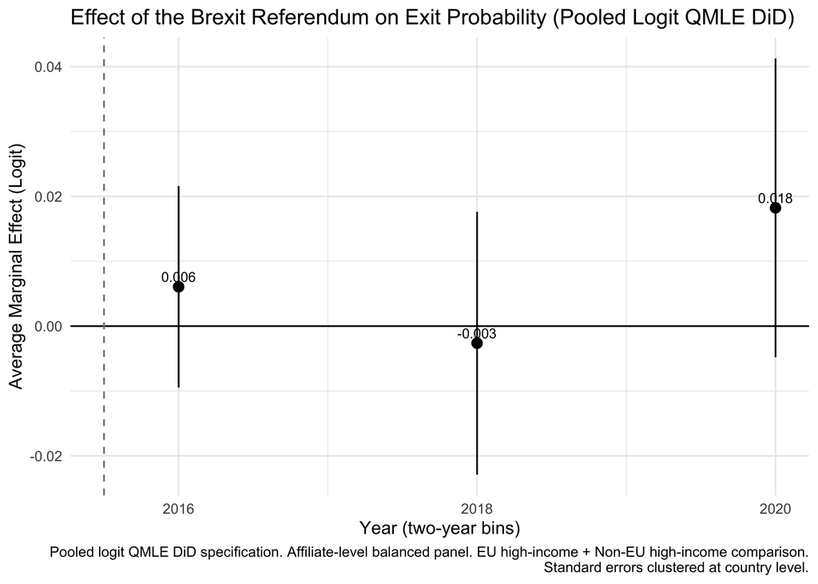

```r
es_etwfe_logit_comb_me$year <- es_etwfe_logit_comb_me$event + 2016

ggplot(es_etwfe_logit_comb_me, aes(x = year, y = estimate,
                                    ymin = conf.low, ymax = conf.high)) +
  geom_hline(yintercept = 0) +
  geom_vline(xintercept = 2015.5, linetype = "dashed", color = "grey50") +
  geom_pointrange() +
  geom_text(aes(label = round(estimate, 3)), vjust = -0.5, hjust = 0.5, size = 3) +
  scale_x_continuous(breaks = c(2016, 2018, 2020)) +
  labs(x = "Year (two-year bins)", y = "Average Marginal Effect (Logit)",
       title = "Effect of the Brexit Referendum on Exit Probability (Pooled Logit QMLE DiD)",
       caption = "Pooled logit QMLE DiD specification. Affiliate-level balanced panel. EU high-income + Non-EU high-income comparison.\nStandard errors clustered at country level.") +
  theme_minimal()
```

# 7 Estimation Table

```r
library(kableExtra)

# Helper: format one model's coefficients into label/coef_fmt/se_fmt
fmt_twfe <- function(model) {
  ct <- as.data.frame(fixest::coeftable(model, vcov = ~country))
  ct$label <- c("UK $\\times$ 2010", "UK $\\times$ 2012",
                "UK $\\times$ 2016", "UK $\\times$ 2018",
                "UK $\\times$ 2020")
  ct$stars <- ifelse(ct$`Pr(>|t|)` < 0.001, "***",
               ifelse(ct$`Pr(>|t|)` < 0.01,  "**",
               ifelse(ct$`Pr(>|t|)` < 0.05,  "*", "")))
  ct$coef_fmt <- paste0(formatC(ct$Estimate,    digits=3, format="f"), ct$stars)
  ct$se_fmt   <- paste0("(", formatC(ct$`Std. Error`, digits=3, format="f"), ")")
  ct[, c("label","coef_fmt","se_fmt")]
}

fmt_logit <- function(me) {
  df <- as.data.frame(me)
  df$label <- c("UK $\\times$ 2016", "UK $\\times$ 2018",
                "UK $\\times$ 2020")
  df$stars <- ifelse(df$p.value < 0.001, "***",
               ifelse(df$p.value < 0.01,  "**",
               ifelse(df$p.value < 0.05,  "*", "")))
  df$coef_fmt <- paste0(formatC(df$estimate,   digits=3, format="f"), df$stars)
  df$se_fmt   <- paste0("(", formatC(df$std.error, digits=3, format="f"), ")")
  df[, c("label","coef_fmt","se_fmt")]
}

# Format all four models
d1 <- fmt_twfe(es_twfe)
d2 <- fmt_logit(es_etwfe_logit_me)
d3 <- fmt_twfe(es_twfe_comb)
d4 <- fmt_logit(es_etwfe_logit_comb_me)

# Build coefficient rows
all_labels <- c("UK $\\times$ 2010", "UK $\\times$ 2012",
                "UK $\\times$ 2016", "UK $\\times$ 2018",
                "UK $\\times$ 2020")

get_val <- function(df, lbl, col) {
  idx <- which(df$label == lbl)
  if (length(idx) == 0) "" else df[[col]][idx]
}

# Interleave coef and SE rows for 4 columns
tab_long <- data.frame()
for (lbl in all_labels) {
  tab_long <- rbind(tab_long, data.frame(
    Term = lbl,
    C1   = get_val(d1, lbl, "coef_fmt"),
    C2   = get_val(d2, lbl, "coef_fmt"),
    C3   = get_val(d3, lbl, "coef_fmt"),
    C4   = get_val(d4, lbl, "coef_fmt"),
    stringsAsFactors = FALSE))
  tab_long <- rbind(tab_long, data.frame(
    Term = "",
    C1   = get_val(d1, lbl, "se_fmt"),
    C2   = get_val(d2, lbl, "se_fmt"),
    C3   = get_val(d3, lbl, "se_fmt"),
    C4   = get_val(d4, lbl, "se_fmt"),
    stringsAsFactors = FALSE))
}

# GOF rows
fmt_n   <- function(m) formatC(as.numeric(m$nobs), format="d", big.mark=",")
fmt_r2  <- function(m) formatC(r2(m)["r2"],  digits=3, format="f")
fmt_pr2 <- function(m) formatC(r2(m)["pr2"], digits=3, format="f")

gof_rows <- data.frame(
  Term = c("Observations", "R-squared", "Pseudo R-squared", "Affiliate FE", "Group FE", "Two-year Period FE"),
  C1   = c(fmt_n(es_twfe),             fmt_r2(es_twfe),        "",                      "Yes", "No",  "Yes"),
  C2   = c(fmt_n(es_etwfe_logit),      "",                     fmt_pr2(es_etwfe_logit), "No",  "Yes", "Yes"),
  C3   = c(fmt_n(es_twfe_comb),        fmt_r2(es_twfe_comb),   "",                      "Yes", "No",  "Yes"),
  C4   = c(fmt_n(es_etwfe_logit_comb), "",                     fmt_pr2(es_etwfe_logit_comb), "No", "Yes", "Yes"),
  stringsAsFactors = FALSE
)
tab_long <- rbind(tab_long, gof_rows)

col_names <- c("", "(1) TWFE OLS", "(2) Pooled Logit QMLE DiD",
                   "(3) TWFE OLS", "(4) Pooled Logit QMLE DiD")
longnote <- "Columns (1)--(2): comparison group = CAN, AUS, CHE, KOR, NZL. Columns (3)--(4): comparison group = EU high-income (AUT, BEL, DEU, DNK, FIN, FRA, IRL, ITA, LUX, NLD, SWE) plus CAN, AUS, CHE, KOR, NZL. Odd columns: OLS estimates from the TWFE event study model with affiliate and two-year period fixed effects (reference period: 2014--2015). Even columns: average marginal effects from the pooled logit QMLE DiD specification following \\\\citet{wooldridge2023simple}. Standard errors clustered at the country level in parentheses. * $p<0.05$, ** $p<0.01$, *** $p<0.001$."

# HTML
kable(tab_long, col.names = col_names,
      caption = "Effect of the Brexit Referendum on Exit Probability",
      align   = c("l","c","c","c","c"), escape = FALSE) %>%
  kable_styling(bootstrap_options = "striped") %>%
  add_header_above(c(" "=1, "Non-EU HI"=2, "EU HI + Non-EU HI"=2)) %>%
  footnote(general = longnote, threeparttable = TRUE)
```

Effect of the Brexit Referendum on Exit Probability

Non-EU HI

EU HI + Non-EU HI

1. TWFE OLS
2. Pooled Logit QMLE DiD
3. TWFE OLS
4. Pooled Logit QMLE DiD

UK $\times$ 2010

-0.049*

-0.026

(0.015)

(0.017)

UK $\times$ 2012

-0.020

-0.011

(0.010)

(0.009)

UK $\times$ 2016

0.016

0.001

0.013

0.006

(0.006)

(0.008)

(0.008)

(0.008)

UK $\times$ 2018

0.011

-0.013

0.008

-0.003

(0.016)

(0.014)

(0.012)

(0.010)

UK $\times$ 2020

0.031

0.003

0.031*

0.018

(0.018)

(0.015)

(0.014)

(0.012)

Observations

10,170

10,170

17,358

17,358

R-squared

0.655

0.661

Pseudo R-squared

0.131

0.129

Affiliate FE

Yes

No

Yes

No

Group FE

No

Yes

No

Yes

Two-year Period FE

Yes

Yes

Yes

Yes

Note:

Columns (1)–(2): comparison group = CAN, AUS, CHE, KOR, NZL. Columns (3)–(4): comparison group = EU high-income (AUT, BEL, DEU, DNK, FIN, FRA, IRL, ITA, LUX, NLD, SWE) plus CAN, AUS, CHE, KOR, NZL. Odd columns: OLS estimates from the TWFE event study model with affiliate and two-year period fixed effects (reference period: 2014–2015). Even columns: average marginal effects from the pooled logit QMLE DiD specification following \citet{wooldridge2023simple}. Standard errors clustered at the country level in parentheses. * $p&lt;0.05$, ** $p&lt;0.01$, *** $p&lt;0.001$.

```r
# LaTeX
tab3_latex <- kable(tab_long, col.names = col_names,
      caption = "Effect of the Brexit Referendum on Exit Probability",
      label   = "noneu",
      format  = "latex", booktabs = TRUE, linesep = "",
      align   = c("l","c","c","c","c"), escape = FALSE) %>%
  kable_styling(latex_options = c("hold_position")) %>%
  add_header_above(c(" "=1, "Non-EU HI"=2, "EU HI + Non-EU HI"=2)) %>%
  footnote(general = longnote, threeparttable = TRUE,
           escape = FALSE, general_title = "Notes: ")

save_kable(tab3_latex, "../../04_tex/main/Tab3.tex")

tab3_tex <- readLines("../../04_tex/main/Tab3.tex", warn = FALSE)
tab3_tex <- gsub("\\\\begin\\{table\\}\\[!h\\]", "\\\\begin{table}[!ht]", tab3_tex)
tab3_tex <- gsub("\\\\textit\\{\\\\textit\\{Notes:\\} \\}", "\\\\textit{Notes: }", tab3_tex)
writeLines(tab3_tex, "../../04_tex/main/Tab3.tex")
```